# How an ANOVA IS A REGRESSION WIHT DUMMY VARIABLES

Bill Perry

# Introduction

This document demonstrates how Analysis of Variance (ANOVA) is mathematically equivalent to a regression model with dummy variables using an example with R code and visualizations.

# Setup and Data Creation

Let’s begin by loading necessary packages and creating a dataframe about plant heights with three different fertilizer treatments.

| fertilizer | height |
| --- | --- |
| A | 10 |
| A | 12 |
| A | 8 |
| B | 14 |
| B | 16 |
| B | 18 |
| C | 20 |
| C | 22 |
| C | 24 |

# Calculating Group Means (ANOVA Approach)

In ANOVA, we calculate the mean of each group and compare variation between groups to variation within groups.

| fertilizer | mean_height |
| --- | --- |
| A | 10 |
| B | 16 |
| C | 22 |

Let’s visualize the raw data and group means:

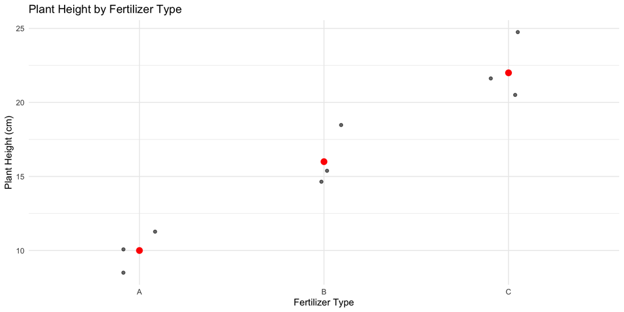

# Running the ANOVA

```
            Df Sum Sq Mean Sq F value Pr(>F)
fertilizer   2    216     108      27  0.001 **
Residuals    6     24       4
---
Signif. codes:  0 '***' 0.001 '**' 0.01 '*' 0.05 '.' 0.1 ' ' 1
```

# Regression with Dummy Variables

For the regression approach, we’ll create dummy variables for fertilizer types, using fertilizer A as the reference level.

```
Call:
lm(formula = height ~ fertilizer, data = fertilizer_data)

Residuals:
   Min     1Q Median     3Q    Max
    -2     -2      0      2      2

Coefficients:
            Estimate Std. Error t value Pr(>|t|)
(Intercept)   10.000      1.155   8.660 0.000131 ***
fertilizerB    6.000      1.633   3.674 0.010402 *
fertilizerC   12.000      1.633   7.348 0.000325 ***
---
Signif. codes:  0 '***' 0.001 '**' 0.01 '*' 0.05 '.' 0.1 ' ' 1

Residual standard error: 2 on 6 degrees of freedom
Multiple R-squared:    0.9, Adjusted R-squared:  0.8667
F-statistic:    27 on 2 and 6 DF,  p-value: 0.001
```

# Understanding the Regression Coefficients

In our regression model:

- The intercept (10) is equal to the mean of the reference group (A)
- The coefficient for fertilizer B (6) is the difference between mean of group B and mean of group A
- The coefficient for fertilizer C (12) is the difference between mean of group C and mean of group A

| Term | Coefficient | Meaning | Mathematical_Expression | Numeric_Value |
| --- | --- | --- | --- | --- |
| Intercept | 10.00 | Mean of Group A (reference group) | β₀ = μA | 10 |
| fertilizerB | 6.00 | Difference between Group B and Group A means | β₁ = μB - μA | 16 - 10 = 6 |
| fertilizerC | 12.00 | Difference between Group C and Group A means | β₂ = μC - μA | 22 - 10 = 12 |

Let’s visualize these coefficients:

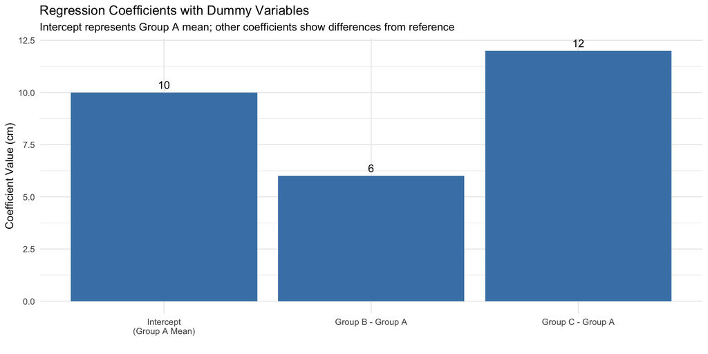

# Demonstrating the Equivalence

Let’s visualize this equivalence:

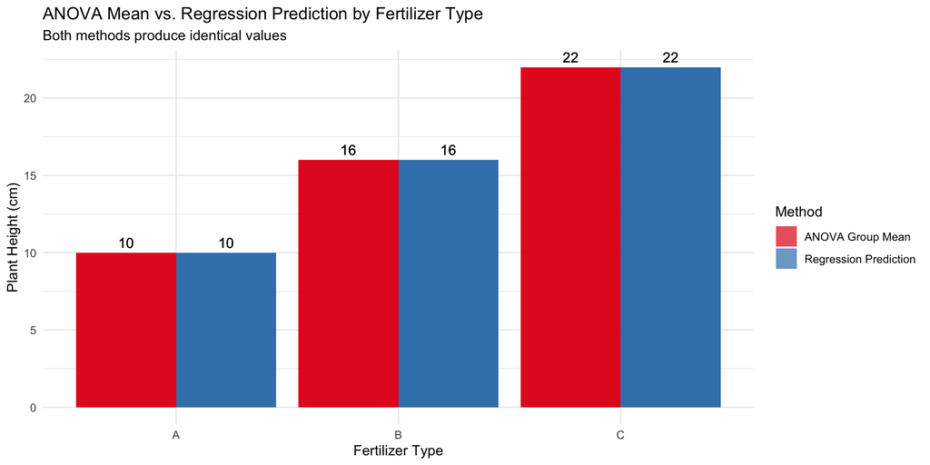

# Comparing Statistical Tests

Both ANOVA and regression provide an F-test. Let’s compare them:

| Test | F-value | p-value |
| --- | --- | --- |
| ANOVA F-test | 27.0000 | 0.0010 |
| Regression F-test | 27.0000 | 0.0010 |

# The Mathematical Relationship

For a one-way ANOVA with a categorical variable having `k` levels, we can express the relationship with regression as:

$$Y = \beta_0 + \beta_1X_1 + \beta_2X_2 + ... + \beta_{k-1}X_{k-1} + \epsilon$$

Where: - $\beta_0$ is the mean of the reference group - $\beta_1, \beta_2, ..., \beta_{k-1}$ are the differences between each group’s mean and the reference group mean - $X_1, X_2, ..., X_{k-1}$ are dummy variables (0 or 1)

In our example: - $\beta_0 = 10$ (mean of group A) - $\beta_1 = 6$ (difference between B and A) - $\beta_2 = 12$ (difference between C and A)

# Conclusion

This demonstration shows that one-way ANOVA is mathematically equivalent to regression with dummy variables. The key equivalences are:

1. ANOVA group means = Regression predictions for each group
2. F-statistic from ANOVA = F-statistic from regression
3. p-values are identical in both approaches

This confirms that both techniques are special cases of the General Linear Model, just expressed in different ways. For a categorical predictor with `k` levels, we need `k-1` dummy variables in the regression approach, with one level serving as the reference category.